# Does faculty salary vary by gender and/or rank?

## Set up

Before getting started, the only addtional library you should have to install (that did not come with the anaconda python distribution) is `seaborn`, a package for visualization:

```
pip install seaborn
```

Let's begin by reading in some data from [this course website](http://data.princeton.edu/wws509/datasets/#salary). Columns included are:

- **sx** = Sex, coded 1 for female and 0 for male
- **rk** = Rank, coded
  - 1 for assistant professor,
  - 2 for associate professor, and
  - 3 for full professor
- **yr** = Number of years in current rank
- **dg** = Highest degree, coded 1 if doctorate, 0 if masters
- **yd** = Number of years since highest degree was earned
- **sl** = Academic year salary, in dollars.

Before performing the statistical analysis here, you should run the `exploratory-analysis` file to get to know your data.

## Simple linear regression: what is the salary increase associated with each additional year in your current position (`yr`)?

OLS Regression Results

| Dep. Variable: | sl | R-squared: | 0.491 |
| --- | --- | --- | --- |
| Model: | OLS | Adj. R-squared: | 0.481 |
| Method: | Least Squares | F-statistic: | 48.22 |
| Date: | Thu, 21 Dec 2017 | Prob (F-statistic): | 7.34e-09 |
| Time: | 19:29:47 | Log-Likelihood: | -507.38 |
| No. Observations: | 52 | AIC: | 1019. |
| Df Residuals: | 50 | BIC: | 1023. |
| Df Model: | 1 |  |  |
| Covariance Type: | nonrobust |  |  |

|  | coef | std err | t | P>\|t\| | [0.025 | 0.975] |
| --- | --- | --- | --- | --- | --- | --- |
| Intercept | 1.817e+04 | 1003.658 | 18.100 | 0.000 | 1.62e+04 | 2.02e+04 |
| yr | 752.7978 | 108.409 | 6.944 | 0.000 | 535.051 | 970.544 |

| Omnibus: | 5.716 | Durbin-Watson: | 1.430 |
| --- | --- | --- | --- |
| Prob(Omnibus): | 0.057 | Jarque-Bera (JB): | 5.015 |
| Skew: | 0.509 | Prob(JB): | 0.0815 |
| Kurtosis: | 4.130 | Cond. No. | 15.8 |

Assess the fit of your model:

- Describe the *accuracy of your coefficient estimates*. What are your interpretations of the **betas**, their **standard errors**, and their **confidence intervals** for your model?
- Describe the *accuracy of your model*. What is your interpretation of the **R-squared** value?

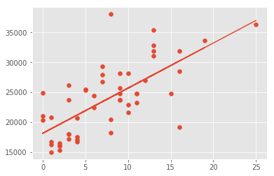

## Multiple Regression

Predict using **multiple** independent variables

OLS Regression Results

| Dep. Variable: | sl | R-squared: | 0.847 |
| --- | --- | --- | --- |
| Model: | OLS | Adj. R-squared: | 0.830 |
| Method: | Least Squares | F-statistic: | 50.82 |
| Date: | Thu, 21 Dec 2017 | Prob (F-statistic): | 1.31e-17 |
| Time: | 19:37:17 | Log-Likelihood: | -476.17 |
| No. Observations: | 52 | AIC: | 964.3 |
| Df Residuals: | 46 | BIC: | 976.0 |
| Df Model: | 5 |  |  |
| Covariance Type: | nonrobust |  |  |

|  | coef | std err | t | P>\|t\| | [0.025 | 0.975] |
| --- | --- | --- | --- | --- | --- | --- |
| Intercept | 1.637e+04 | 757.573 | 21.615 | 0.000 | 1.49e+04 | 1.79e+04 |
| sx[T.male] | -505.6541 | 843.489 | -0.599 | 0.552 | -2203.508 | 1192.200 |
| rk[T.associate] | 4253.7176 | 961.967 | 4.422 | 0.000 | 2317.379 | 6190.056 |
| rk[T.full] | 9508.1038 | 923.022 | 10.301 | 0.000 | 7650.157 | 1.14e+04 |
| dg[T.masters] | 314.4186 | 782.166 | 0.402 | 0.690 | -1260.000 | 1888.837 |
| yr | 385.1491 | 77.415 | 4.975 | 0.000 | 229.322 | 540.977 |

| Omnibus: | 23.460 | Durbin-Watson: | 1.797 |
| --- | --- | --- | --- |
| Prob(Omnibus): | 0.000 | Jarque-Bera (JB): | 41.096 |
| Skew: | 1.408 | Prob(JB): | 1.19e-09 |
| Kurtosis: | 6.323 | Cond. No. | 32.7 |

Assess the fit of your model:

- Describe the *accuracy of your coefficient estimates*. What are your interpretations of the **betas**, their **standard errors**, and their **confidence intervals** for your model?
- Describe the *accuracy of your model*. What is your interpretation of the **R-squared** value?
- What do you find surprising...?

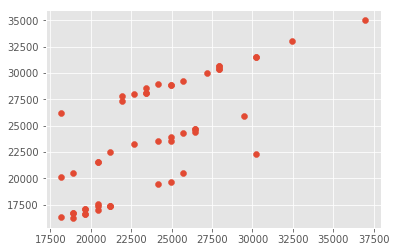

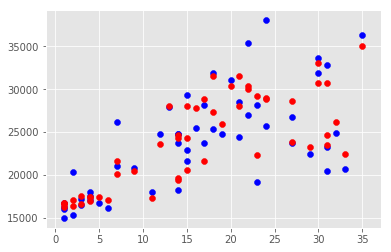

## Assess predictions

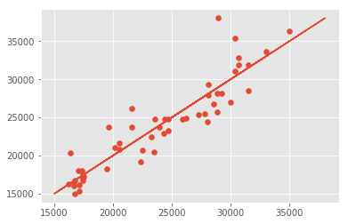

```
0.490937026769 0.846714483761
```

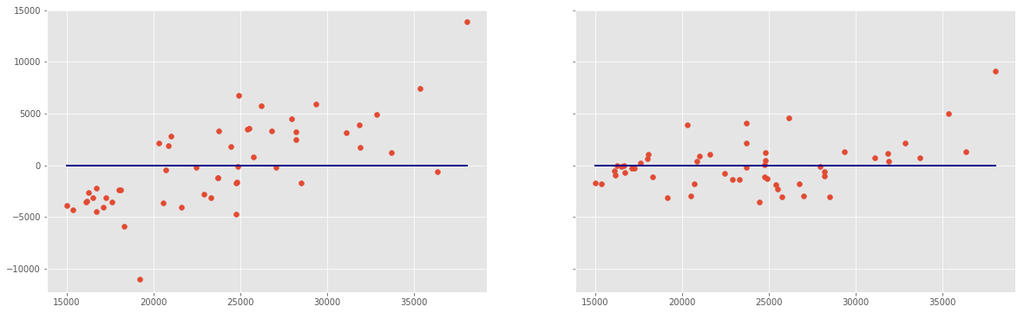